# Assigment: Trend Surfaces

Yunxuan Pei

2021-02-22

# 1 Dataset

Task 1: Load the “Northeast Climate” R Dataset `ne_stations.RData`, with the `load` function. Use the `verbose=TRUE` optional argument to display the names of the objects that are loaded.

```r
load("ne_stations.RData", verbose = TRUE)
```

```
## Loading objects:
##   ne
##   ne.m
##   ne.df
##   state.ne
##   state.ne.m
##   ne.crs
```

Q1: What are the data types of these objects? For those that are spatial, what are their coördinate reference systems (CRS)?

Note: you will have to load the `sp` package to see the CRS.

A:

```r
install.packages("sp")
```

```r
library("sp")
class(ne)
```

```
## [1] "SpatialPointsDataFrame"
## attr(,"package")
## [1] "sp"
```

```r
proj4string(ne)
```

```
## [1] "+proj=longlat +datum=NAD27 +no_defs +ellps=clrk66 +nadgrids=@conus,@alaska,@ntv2_0.gsb,@ntv1_can.dat"
```

```r
class(ne.m)
```

```
## [1] "SpatialPointsDataFrame"
## attr(,"package")
## [1] "sp"
```

```r
proj4string(ne.m)
```

```
## [1] "+proj=aea +lat_0=42.5 +lat_1=39 +lat_2=44 +lon_0=-76 +ellps=WGS84 +units=m"
```

```r
class(ne.df)
```

```
## [1] "data.frame"
```

```r
class(state.ne)
```

```
## [1] "SpatialPolygonsDataFrame"
## attr(,"package")
## [1] "sp"
```

```r
proj4string(state.ne)
```

```
## [1] "+proj=longlat +datum=NAD83 +no_defs +ellps=GRS80 +towgs84=0,0,0"
```

```r
class(state.ne.m)
```

```
## [1] "SpatialPolygonsDataFrame"
## attr(,"package")
## [1] "sp"
```

```r
proj4string(state.ne.m)
```

```
## [1] "+proj=aea +lat_0=42.5 +lat_1=39 +lat_2=44 +lon_0=-76 +ellps=WGS84 +units=m"
```

```r
class(ne.crs)
```

```
## [1] "CRS"
## attr(,"package")
## [1] "sp"
```

We will work mostly with object `ne.df`, a dataframe version of the climate stations.

Q2: For how many climate stations are there records? How many states of the USA are represented?

A:

```r
length(ne.df$STATION_ID)
```

```
## [1] 305
```

```r
levels(ne.df$STATE)
```

```
## [1] "NJ" "NY" "PA" "VT"
```

- There are 305 climate stations in the records.
- There are 4 states (NJ, NY, PA, VT) are represented.

Task 2: Display the names of the variables in this dataset.

```r
names(ne.df)
```

```
##  [1] "STATION_ID" "STATE"      "STATION_NA" "LATITUDE_D" "LONGITUDE_"
##  [6] "ELEVATION_" "OID_"       "COOP_ID"    "STATE_1"    "STN_NAME"
## [11] "LAT_DD"     "LONG_DD"    "ELEV_FT"    "JAN_GDD50"  "FEB_GDD50"
## [16] "MAR_GDD50"  "APR_GDD50"  "MAY_GDD50"  "JUN_GDD50"  "JUL_GDD50"
## [21] "AUG_GDD50"  "SEP_GDD50"  "OCT_GDD50"  "NOV_GDD50"  "DEC_GDD50"
## [26] "ANN_GDD50"  "E"          "N"
```

Q3: What are the attributes in the `ne.df` data frame?

A:

- Attributes in the `ne.df` data frame are “STATION_ID” “STATE” “STATION_NA” “LATITUDE_D” “LONGITUDE_” “ELEVATION_” “OID_” “COOP_ID” “STATE_1” “STN_NAME” “LAT_DD” “LONG_DD” “ELEV_FT” “JAN_GDD50” “FEB_GDD50” “MAR_GDD50” “APR_GDD50” “MAY_GDD50” “JUN_GDD50” “JUL_GDD50” “AUG_GDD50” “SEP_GDD50” “OCT_GDD50” “NOV_GDD50” “DEC_GDD50” “ANN_GDD50” “E” “N”.

The response variable here is `ANN_GDD50` (annual growing-degree days), the coördinates are in fields `E` and `N`, the elevation of the station is in field `ELEVATION_`.

# 2 First-order trend surface

Task 3: Compute a first-order trend surface model using the two coordinates (East and North) as the predictors, and the growing degree days as the dependent (response) variable, using Ordinary Least Squares linear regression.

```r
model_t3 <- lm(ANN_GDD50 ~ E + N, data = ne.df)
```

Display its summary and the linear model diagnostic plots “residuals vs. fitted” and “Normal Q-Q”.

```r
summary(model_t3)
```

```
##
## Call:
## lm(formula = ANN_GDD50 ~ E + N, data = ne.df)
##
## Residuals:
##      Min       1Q   Median       3Q      Max
## -1207.36  -232.79    27.11   259.59   847.42
##
## Coefficients:
##               Estimate Std. Error t value Pr(>|t|)
## (Intercept)  2.298e+03  2.381e+01  96.478  < 2e-16 ***
## E            7.483e-04  1.211e-04   6.181 2.07e-09 ***
## N           -2.818e-03  1.369e-04 -20.577  < 2e-16 ***
## ---
## Signif. codes:  0 '***' 0.001 '**' 0.01 '*' 0.05 '.' 0.1 ' ' 1
##
## Residual standard error: 371.5 on 302 degrees of freedom
## Multiple R-squared:  0.5837, Adjusted R-squared:  0.581
## F-statistic: 211.7 on 2 and 302 DF,  p-value: < 2.2e-16
```

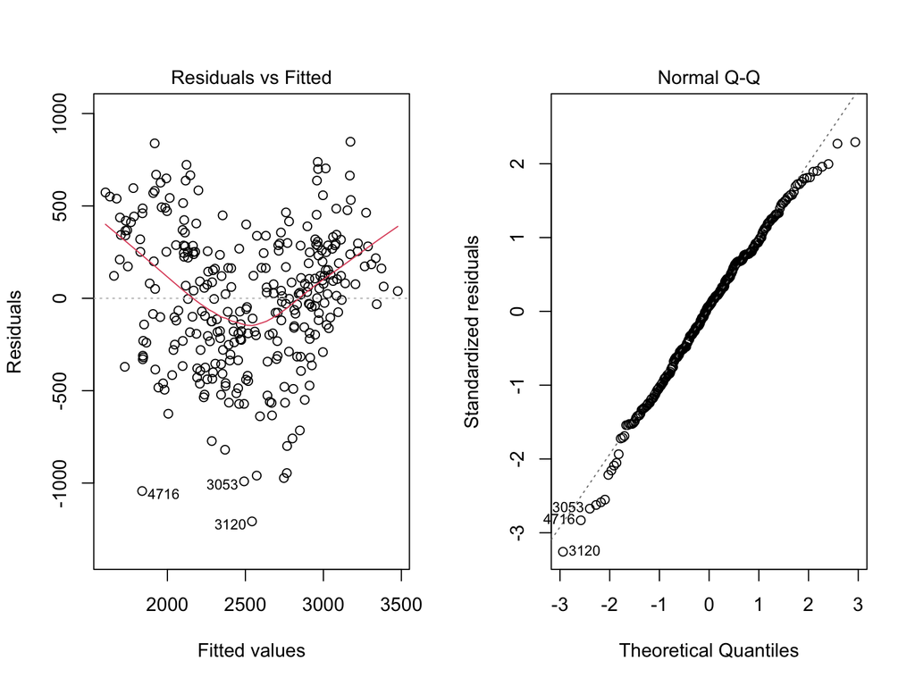

```r
par(mfrow = c(1,2))
plot(model_t3, which = 1:2)
```

Q4: What proportion of the variation in GDD50 is explained by the first-order trend?

A:

- The proportion of variability explained is 0.58.

Q5: Which of the two coördinates most affects the GDD50?

A:

Q6: Is there a relation between the fitted values and residuals? If so, what?

A:

- There is a relation between residuals and fitted values: residuals at both extremes are positive (under-predictions); in the mid-range most residuals are negative (over-predictions). Mean residual is not 0 through the range of fitted values.

Q7: Are the residuals normally-distributed? If not, how so? Are there any especially large residuals?

A:

- Extreme residuals are not from a normal distribution. There are some extreme value influence the residuals distribution.

Optional Task: Identify the most poorly-modelled station.

Optional Q: Where is this? Why might it be so poorly modelled?

Optional A:

Task 4: Display a post-plot of the residuals, with the positive residuals (under-predictions) shown in green and the negative (over-predictions) in red.

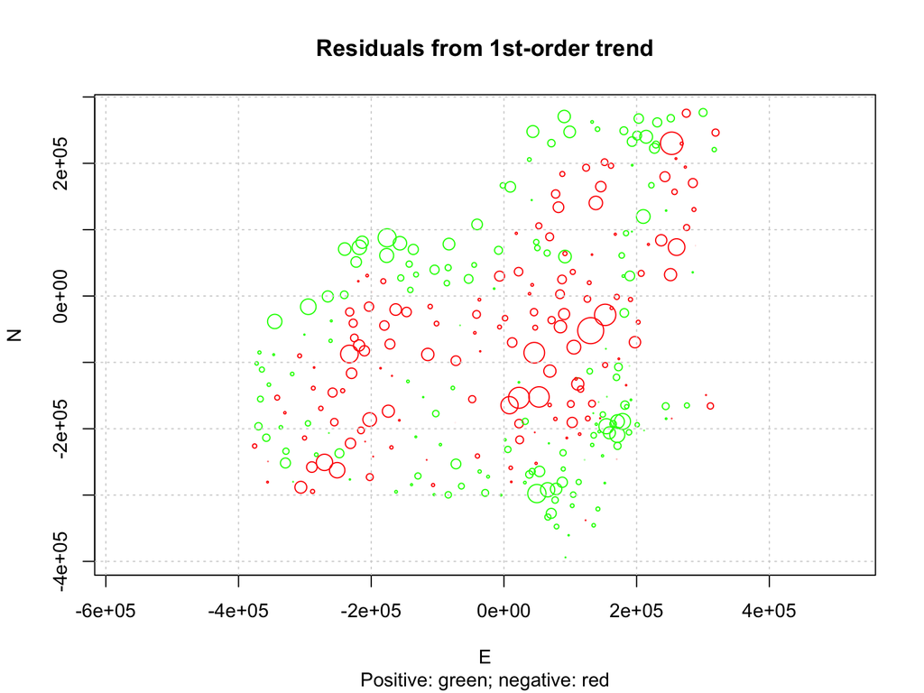

```r
res_t3 <- residuals(model_t3)
plot(ne.df$N ~ ne.df$E, cex=3*abs(res_t3)/max(abs(res_t3)), col=ifelse(res_t3 > 0, "green", "red"), xlab="E", ylab="N",
main="Residuals from 1st-order trend", sub="Positive: green; negative: red", asp=1)
grid()
```

Q8: What is the spatial pattern of the trend-surface residuals? Does it suggest a higher-order trend?

A:

- Spatial pattern: large residuals tend to be near each other, and vice-versa. It suggests a higher-order trend.

# 3 Second-order trend surface

Task 5: Repeat all the steps of the previous section, and answer the same questions, for a full 2nd-order trend surface.

```r
model_t5 <- lm(ANN_GDD50 ~ E + N + I(E^2) + I(N^2) +I(E*N),
               data = ne.df)
```

Q9: What proportion of the variation in GDD50 is explained by the second-order trend?

A:

```r
summary(model_t5)
```

```
##
## Call:
## lm(formula = ANN_GDD50 ~ E + N + I(E^2) + I(N^2) + I(E * N),
##     data = ne.df)
##
## Residuals:
##      Min       1Q   Median       3Q      Max
## -1076.18  -214.61    37.77   229.11   792.40
##
## Coefficients:
##               Estimate Std. Error t value Pr(>|t|)
## (Intercept)  2.131e+03  3.529e+01  60.402  < 2e-16 ***
## E           -8.336e-05  1.444e-04  -0.577    0.564
## N           -1.523e-03  1.788e-04  -8.520 7.95e-16 ***
## I(E^2)       2.821e-09  6.927e-10   4.073 5.95e-05 ***
## I(N^2)       7.526e-09  8.380e-10   8.981  < 2e-16 ***
## I(E * N)    -8.036e-09  9.691e-10  -8.292 3.84e-15 ***
## ---
## Signif. codes:  0 '***' 0.001 '**' 0.01 '*' 0.05 '.' 0.1 ' ' 1
##
## Residual standard error: 323.9 on 299 degrees of freedom
## Multiple R-squared:  0.6868, Adjusted R-squared:  0.6816
## F-statistic: 131.1 on 5 and 299 DF,  p-value: < 2.2e-16
```

- The proportion of variability explained is 0.68.

Q10: Which of the two coördinates (taking into account their squares also) most affects the GDD50?

A:

Q11: Is there a relation between the fitted values and residuals? If so, what?

A:

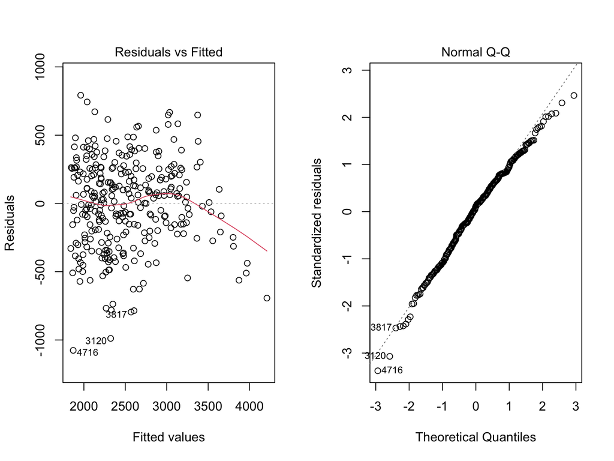

```r
par(mfrow = c(1,2))
plot(model_t5, which = 1:2)
```

- Relation of fits vs. residuals seen in 1st order trend has been removed. But systematic over-prediction of highest values.

Q12: Are the residuals normally-distributed? If not, how so? Are there any especially large residuals?

A:

- No, they are not normally distributed. There are over-prediction of highest values. There are especially large residuals.

Optional Task: Identify the most poorly-modelled station.

Optional Q: Where is this? Why might it be so poorly modelled?

Optional A:

Task 6: Display a post-plot of the residuals, with the positive residuals (under-predictions) shown in green and the negative (over-predictions) in red.

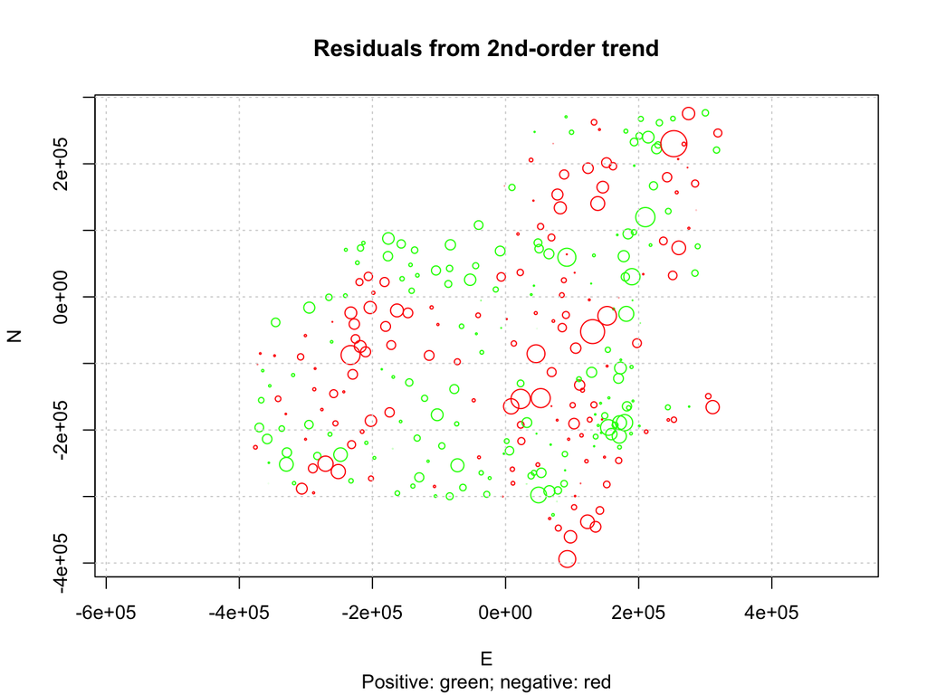

```r
res_t5 <- residuals(model_t5)
plot(ne.df$N ~ ne.df$E, cex=3*abs(res_t5)/max(abs(res_t5)), col=ifelse(res_t5 > 0, "green", "red"), xlab="E", ylab="N", main="Residuals from 2nd-order trend", sub="Positive: green; negative: red", asp=1)
grid()
```

Q13: What is the spatial pattern of the trend-surface residuals? Does it suggest a higher-order trend?

A:

- These residuals form local clusters of positive, negative, and near-zero; there does not appear to be any overall spatial pattern. So, a higher-order trend surface is not indicated.

# 4 Comparing trend orders

Task 7: Compare the two orders of trend surfaces with an analysis of variance.

```r
anova(model_t3, model_t5)
```

```
## Analysis of Variance Table
##
## Model 1: ANN_GDD50 ~ E + N
## Model 2: ANN_GDD50 ~ E + N + I(E^2) + I(N^2) + I(E * N)
##   Res.Df      RSS Df Sum of Sq     F    Pr(>F)
## 1    302 41685611
## 2    299 31361422  3  10324189 32.81 < 2.2e-16 ***
## ---
## Signif. codes:  0 '***' 0.001 '**' 0.01 '*' 0.05 '.' 0.1 ' ' 1
```

Q14: Is the 2nd-order trend clearly superior to the 1st-order trend?

A:

- P-values are `***`, suggesting that most independent variables are significant at 0.000 level, so the second-order surface is statistically superior to the first-order surface.

# 5 Mapping

Task 8: Load the `raster` package into the workspace.

```r
install.packages("raster")
```

Then, load a gridded DEM covering the study area `dem_nj_ny_pa_vt_4km.RData`, with the `load` function. Use the `verbose=TRUE` optional argument to display the names of the objects that are loaded.

```r
load("dem_nj_ny_pa_vt_4km.RData", verbose = TRUE)
```

```
## Loading objects:
##   dem.ne.m.sp
```

Q15: What object is loaded? What is its class? What is its CRS? Which of the point datasets does this match?

A:

- Loading objects: `dem.ne.m.sp`

```r
class(dem.ne.m.sp)
```

```
## [1] "SpatialPixelsDataFrame"
## attr(,"package")
## [1] "sp"
```

```r
proj4string(dem.ne.m.sp)
```

```
## [1] "+proj=aea +lat_0=42.5 +lat_1=39 +lat_2=44 +lon_0=-76 +ellps=WGS84 +units=m"
```

Q16: What is the bounding box and resolution of the grid? (You can see these with the `summary` function.)

A:

```r
summary(dem.ne.m.sp)
```

```
## Object of class SpatialPixelsDataFrame
## Coordinates:
##         min      max
## E -385999.3 355750.7
## N -395302.4 289937.6
## Is projected: TRUE
## proj4string :
## [+proj=aea +lat_0=42.5 +lat_1=39 +lat_2=44 +lon_0=-76 +ellps=WGS84
## +units=m]
## Number of points: 22649
## Grid attributes:
##   cellcentre.offset cellsize cells.dim
## E         -384274.3     3450       216
## N         -393450.4     3704       185
## Data attributes:
##    ELEVATION_
##  Min.   :  -6.697
##  1st Qu.: 602.504
##  Median :1173.889
##  Mean   :1125.085
##  3rd Qu.:1587.356
##  Max.   :3992.470
```

- bounding box

```r
range(dem.ne.m.sp$E)
```

```
## [1] -384274.3  354025.7
```

```r
range(dem.ne.m.sp$N)
```

```
## [1] -393450.4  288085.6
```

- The resolution of grid is 3450m * 3704m.

Task 9: Display the grid with the `spplot` function.

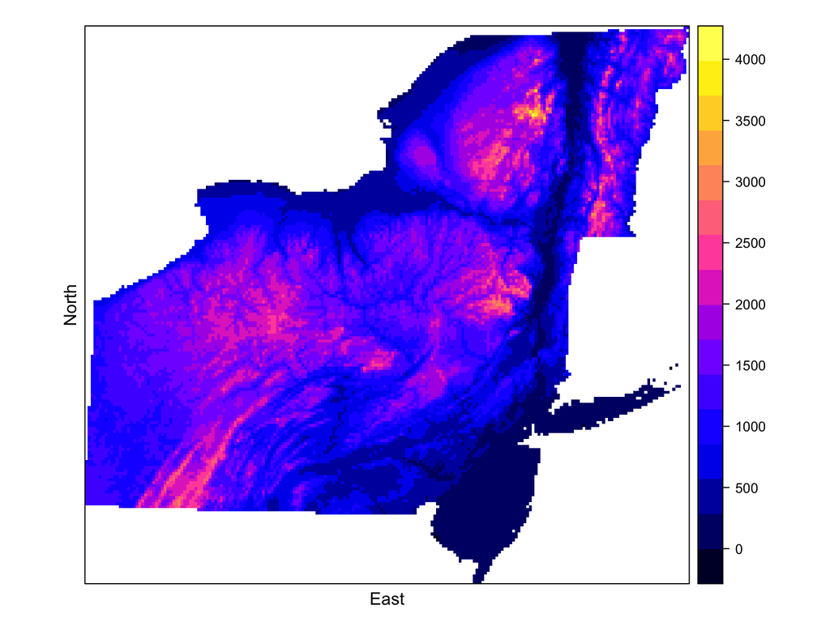

```r
(grid_t9 <- spplot(dem.ne.m.sp, xlab="East", ylab="North"))
```

Task 10: Predict over this study area with the 2nd-order trend surface. Add this as a field in the study area data frame.

```r
pred_t10 <- predict.lm(model_t5, newdata = as.data.frame(dem.ne.m.sp))
dem.ne.m.sp$PRED_2ndTS <- predict(model_t5, newdata=as.data.frame(dem.ne.m.sp))
```

Task 11: Summarize the predictions.

```r
summary(pred_t10)
```

```
##    Min. 1st Qu.  Median    Mean 3rd Qu.    Max.
##    1822    2087    2332    2413    2630    4227
```

Q17: How do the predictions compare with the summary of the weather stations observations?

```r
summary(ne.df$ANN_GDD50)
```

```
##    Min. 1st Qu.  Median    Mean 3rd Qu.    Max.
##     795    2100    2463    2518    2930    4021
```

```r
summary(pred_t10)
```

```
##    Min. 1st Qu.  Median    Mean 3rd Qu.    Max.
##    1822    2087    2332    2413    2630    4227
```

A:

Task 12: Display a map of the predictions using the `spplot` function, and specifying the field to display with the `zcol` argument to `spplot`.

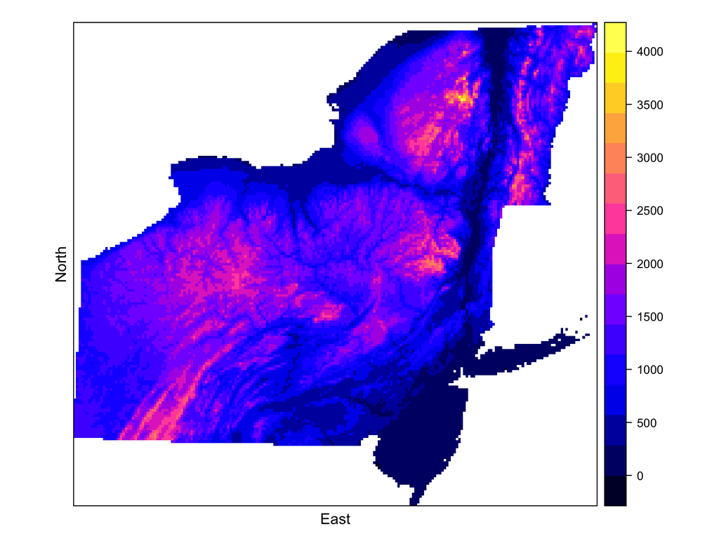

```r
(grid_t12 <- spplot(dem.ne.m.sp, zcol="ELEVATION_",
                    xlab="East", ylab="North"))
```

[output not shown]

Q18: Is this trend surface a realistic representation of the growing-degree days? Explain.

A:

# 6 Generalized Additive Model (GAM)

Task 13: Display a scatterplot of the GDD50 against the two coördinates.

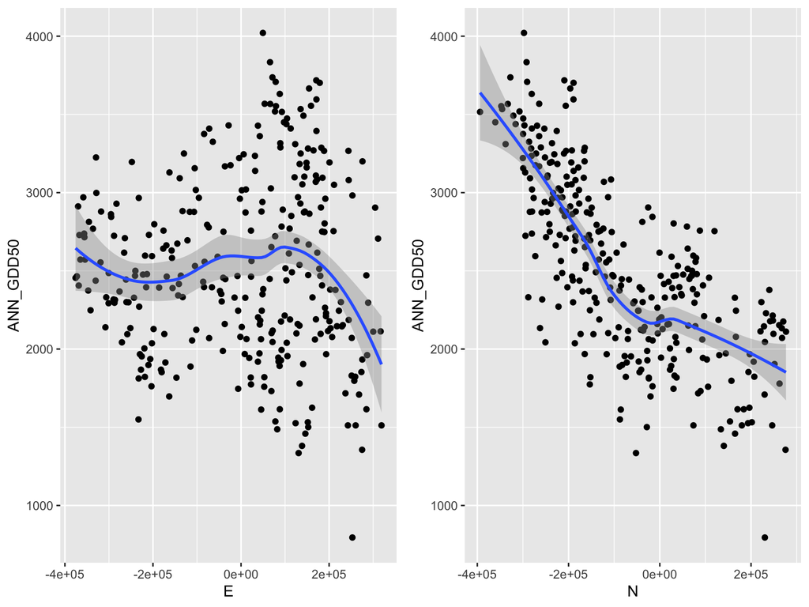

```r
require(ggplot2)
plote_t13 <- ggplot(ne.df, aes(x=E, y=ANN_GDD50)) + geom_point() +
   geom_smooth(method = "loess")
plotn_t13 <- ggplot(ne.df, aes(x=N, y=ANN_GDD50)) + geom_point() +
   geom_smooth(method = "loess")
require(gridExtra)
grid.arrange(plote_t13, plotn_t13, ncol = 2)
```

Q19: Do these relations look linear or quadratic throughout their ranges?

A:

The relation with North seems almost linear. However, the relation with East is much more scattered.

Task 14: Compute a Generalized Additive Model (GAM) of GDD50 modelled by the two coördinates.

```r
require(mgcv)
model_t14 <- gam(ANN_GDD50 ~ s(E, N), data = ne.df)
```

Q20: What proportion of the variation in GDD50 is explained by the GAM? How does this compare to the 2nd-order trend surface?

```r
summary(model_t14)
```

```
##
## Family: gaussian
## Link function: identity
##
## Formula:
## ANN_GDD50 ~ s(E, N)
##
## Parametric coefficients:
##             Estimate Std. Error t value Pr(>|t|)
## (Intercept)  2517.52      15.73     160   <2e-16 ***
## ---
## Signif. codes:  0 '***' 0.001 '**' 0.01 '*' 0.05 '.' 0.1 ' ' 1
##
## Approximate significance of smooth terms:
##          edf Ref.df     F p-value
## s(E,N) 24.46   27.8 36.98  <2e-16 ***
## ---
## Signif. codes:  0 '***' 0.001 '**' 0.01 '*' 0.05 '.' 0.1 ' ' 1
##
## R-sq.(adj) =  0.771   Deviance explained = 78.9%
## GCV =  82348  Scale est. = 75474     n = 305
```

A:

- The proportion of variability explained is 0.77.
- Compared with 2nd-order trend surface, the proportion becomes higher.

Task 15: Predict over this study area with the fitted GAM. Add this as a field in the study area data frame.

```r
pred_t15 <- predict.gam(model_t14, newdata = as.data.frame(dem.ne.m.sp))
dem.ne.m.sp$PRED_GAM <- pred_t15
```

Note: you will have to convert the `SpatialPixelsDataFrame` to a regular `data.frame` as the argument to `newdata`, because `predict.gam` does not recognize `sp` objects.

Task 16: Summarize the predictions.

```r
summary(pred_t15)
```

```
##    Min. 1st Qu.  Median    Mean 3rd Qu.    Max.
##    1634    2047    2281    2396    2667    3633
```

Q21: How do the predictions compare with the summary of the weather stations observations, and to the summary of the 2nd-order trend surface predictions?

A:

```r
summary(ne.df$ANN_GDD50)
```

```
##    Min. 1st Qu.  Median    Mean 3rd Qu.    Max.
##     795    2100    2463    2518    2930    4021
```

```r
summary(pred_t10)
```

```
##    Min. 1st Qu.  Median    Mean 3rd Qu.    Max.
##    1822    2087    2332    2413    2630    4227
```

```r
summary(pred_t15)
```

```
##    Min. 1st Qu.  Median    Mean 3rd Qu.    Max.
##    1634    2047    2281    2396    2667    3633
```

Task 17: Display a post-plot of the residuals.

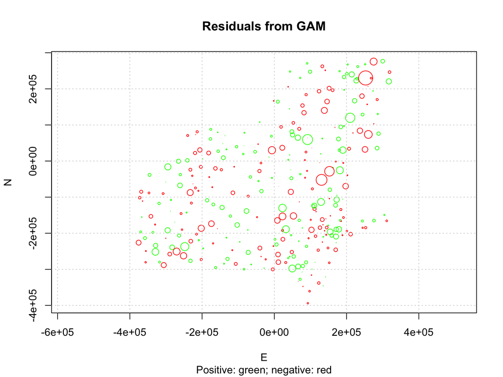

```r
res_t17 <- residuals.gam(model_t14)
plot(ne.df$N ~ ne.df$E, cex=3*abs(res_t17)/max(abs(res_t17)), col=ifelse(res_t17 > 0, "green", "red"), xlab="E", ylab="N",
main="Residuals from GAM", sub="Positive: green; negative: red", asp=1)
grid()
```

Q22: What is the spatial pattern of the GAM trend-surface residuals? How does this differ from the pattern of the 2nd-order trend residuals?

- No residual spatial correlation. Compared with the 2nd-order trend residuals, GAM trend-surface residuals doesn’t appear any spatial pattern.

A:

Task 18: Display a map of the predictions using the `spplot` function.

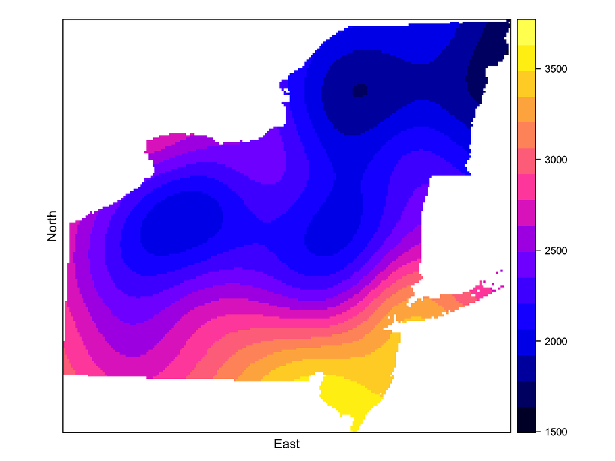

```r
library(sp)
(map_t18 <- spplot(dem.ne.m.sp, zcol="PRED_GAM",
                   xlab="East", ylab="North"))
```

Q23: Is this trend surface a realistic representation of the growing-degree days? Explain. How does it improve on the 2nd-order trend?

A:

# 7 Thin-plate splines

Task: Load the `fields` package, to use for thin-plate spline calculation.

Task: Add a field to the stations dataframe, containing a matrix of the two coördinates, as required by the `fields` package.

Task: compute the thin-plate spline for the growing degree days, as a function of coördinates.

Task: Predict with the thin-plate spline over the study area. Note you will have to make a matrix from the grid coördinates, interpolate on that, and then convert the prediction to a field in the grid.

Task: Display the map.

Q: Is this trend surface a realistic representation of the growing-degree days? Explain. Does it improve on the GAM trend?

A:

# 8 Challenge – including elevation

Of course, elevation also affects temperature and thus the growing-degree days.

Repeat the exercise, but including elevation in all the models. Comment on how and why the trend surfaces (now 3D) are different/improved from the 2D trends.

In these models, consider elevation as an independent dimension, with no interaction with the geographic coördinates (although, that may not be a valid assumption… you could test this… ).

Also, see if a transformation of elevation might make its relation with the target variable more linear.

# 9 Saving the workspace

Task: Save the workspace for a later exercise using the `save.image` function: